# Analisi sul Dataset dei Pokémon

Massimiliano Baldo

2/09/2020

# Introduzione ai Pokémon

> “Cosa faccio io? Conduco delle ricerche in modo che possiamo imparare di più sui Pokémon…  
> Sono sicuro che lungo il percorso scoprirai molte cose, forse anche qualcosa di te stesso.”

[figure not shown]

# Cosa analizzeremo?

- Qual è il tipo più forte nel complesso? Qual è il più debole?
- Qual è il doppio tipo esistente nel complesso il più forte? Qual è il più debole?
- Qual è il tipo più probabile che sia un Pokémon leggendario?
- Come si correla l’altezza e il peso di un Pokémon con le sue varie statistiche di base?
- Si può costruire un dream team Pokémon?  
  Una squadra di 6 Pokémon che rimane relativamente impenetrabile a qualsiasi altra squadra di 6 Pokémon.

# Qual è il tipo più forte nel complesso? Qual è il più debole?

[figure not shown]

[figure not shown]

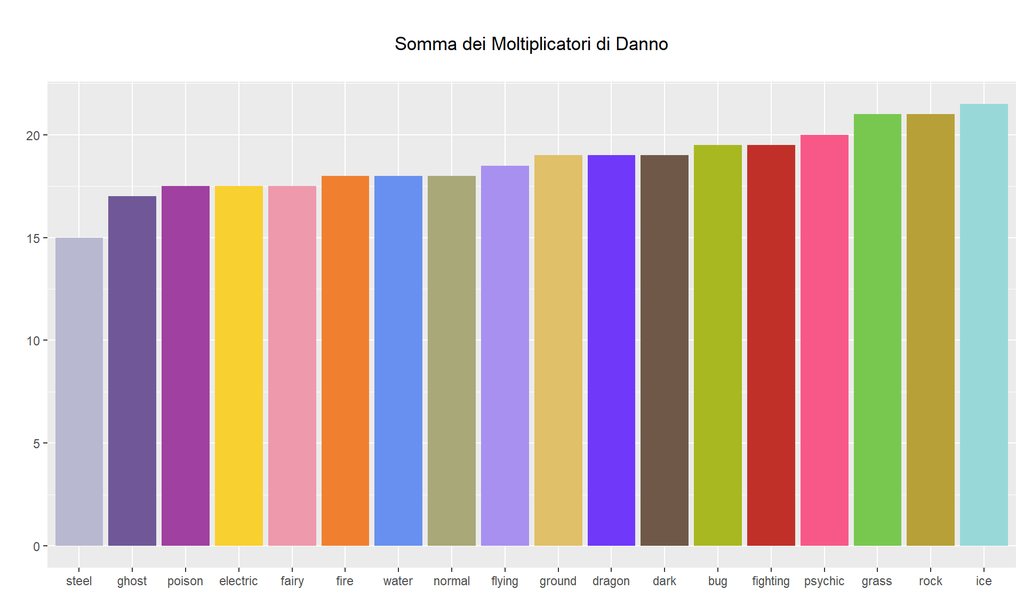

# Qual è il doppio tipo esistente nel complesso il più forte? Qual è il più debole?

| Type 1 | Type 2 | Weak Point |
| --- | --- | --- |
| steel | fairy | 13.25 |
| steel | flying | 13.50 |
| steel | dragon | 14.25 |
| steel | ghost | 14.25 |
| water | steel | 14.50 |
| dark | ghost | 15.50 |

| Type 1 | Type 2 | Weak Point |
| --- | --- | --- |
| psychic | grass | 24.00 |
| rock | ground | 24.25 |
| ground | rock | 24.25 |
| bug | grass | 25.00 |
| grass | ice | 25.00 |
| rock | ice | 26.00 |

# Qual è il tipo più probabile che sia un Pokémon leggendario?

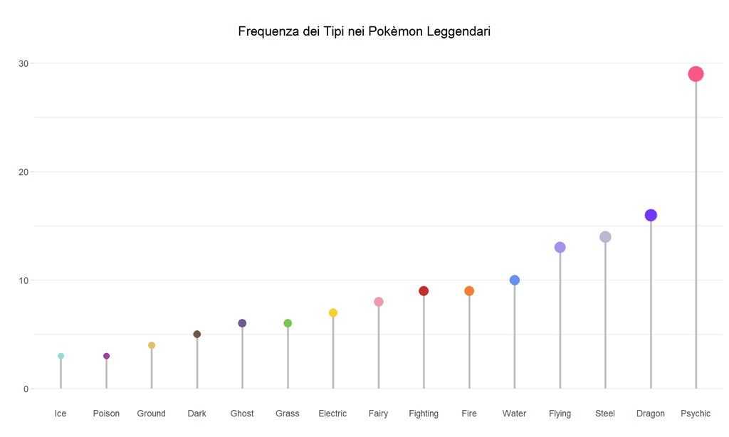

# Come si correla l’altezza e il peso di un Pokémon con le sue varie statistiche di base?

[figure not shown]

# Correlazione Lineare

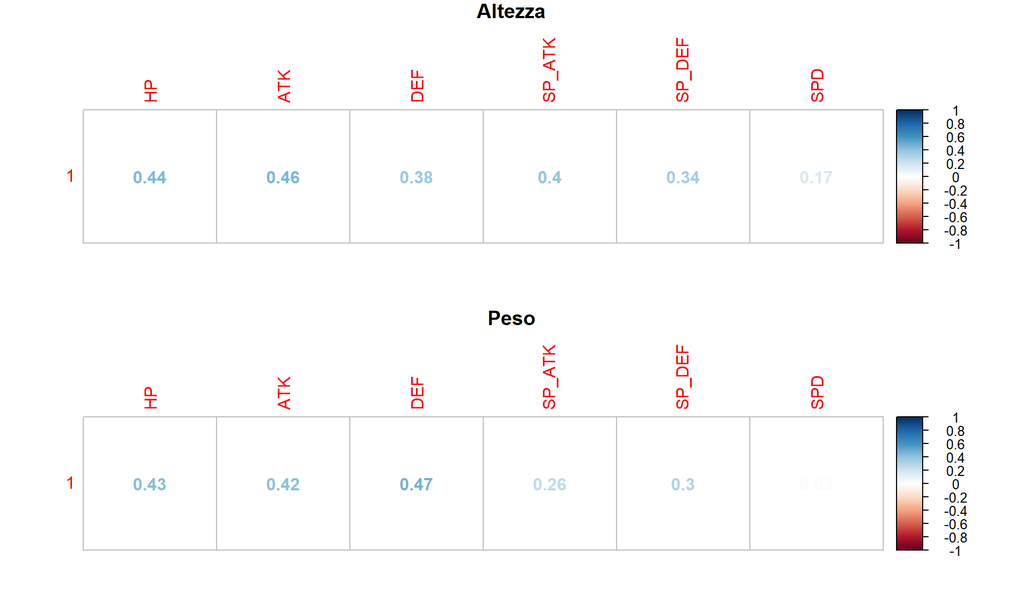

# Correlazione Quadratica

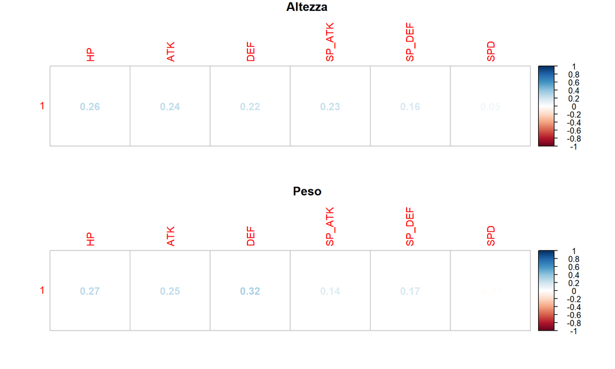

# Correlazione Logaritmica

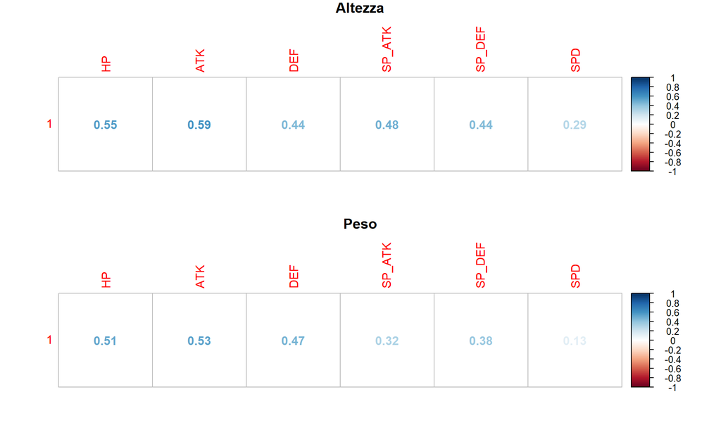

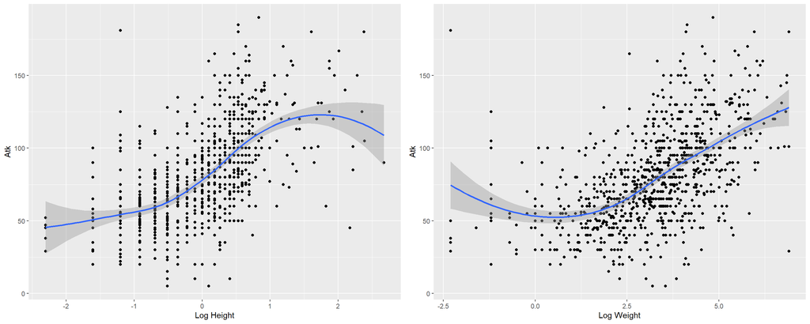

# Si può costruire un dream team Pokémon? Una squadra di 6 Pokémon che rimane relativamente impenetrabile a qualsiasi altra squadra di 6 Pokémon.

> “L’ultimo passo è di gran lunga il più difficile. Anche se è vero che ci sono dei set di mosse”standard" per ogni Pokémon, il più difficile è far lavorare tutti insieme i tuoi Pokémon, non solo per trovare le mosse giuste per il tuo Pokémon."

# Il meno vulnerabile

| bug | dark | dragon | electric | fairy | fight | fire | flying | ghost | grass | ground | ice | normal | poison | psychic | rock | steel | water |
| --- | --- | --- | --- | --- | --- | --- | --- | --- | --- | --- | --- | --- | --- | --- | --- | --- | --- |
| 0.25 | 0.5 | 0 | 1 | 0.5 | 1 | 2 | 0.5 | 1 | 0.5 | 2 | 0.5 | 0.5 | 0 | 0.5 | 0.5 | 1 | 1 |

# Nuovo Membro

| bug | dark | dragon | electric | fairy | fight | fire | flying | ghost | grass | ground | ice | normal | poison | psychic | rock | steel | water |
| --- | --- | --- | --- | --- | --- | --- | --- | --- | --- | --- | --- | --- | --- | --- | --- | --- | --- |
| 0.25 | 0.5 | 0.0 | 1 | 0.5 | 1 | 2 | 0.5 | 1 | 0.50 | 2 | 0.5 | 0.5 | 0 | 0.5 | 0.5 | 1.0 | 1 |
| 0.25 | 1.0 | 0.5 | 2 | 0.5 | 1 | 2 | 0.5 | 1 | 0.25 | 0 | 1.0 | 0.5 | 0 | 0.5 | 1.0 | 0.5 | 1 |

[figure not shown]

# Team finale

| name | type1 | type2 | hp | attack | defense | speed | sp_attack | sp_defense |
| --- | --- | --- | --- | --- | --- | --- | --- | --- |
| Azumarill | water | fairy | 100 | 50 | 80 | 50 | 60 | 80 |
| Steelix | steel | ground | 75 | 125 | 230 | 30 | 55 | 95 |
| Skarmory | steel | flying | 65 | 80 | 140 | 70 | 40 | 70 |
| Mawile | steel | fairy | 50 | 105 | 125 | 50 | 55 | 95 |
| Empoleon | water | steel | 84 | 86 | 88 | 60 | 111 | 101 |
| Aegislash | steel | ghost | 60 | 150 | 50 | 60 | 150 | 50 |

[figure not shown]

[figure not shown]

[figure not shown]

[figure not shown]

[figure not shown]

# È effetivamente un dream team?

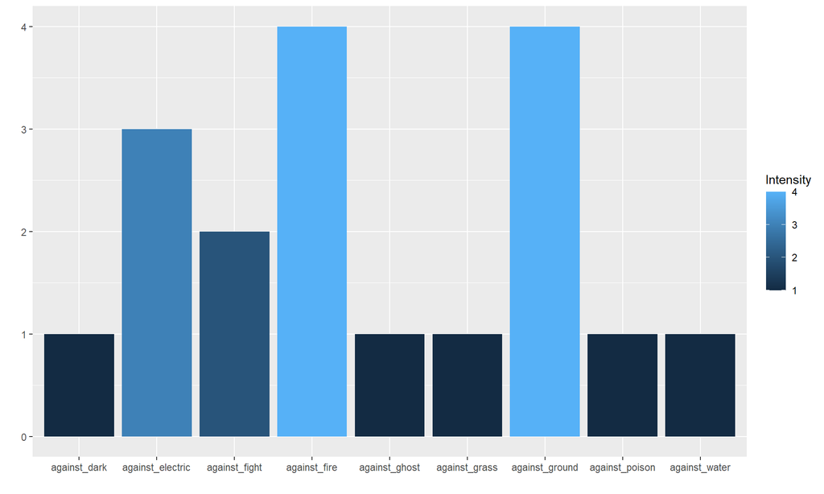

# Bibliografia

- Kaggle
  - [Dataset con i Moltiplicatori di Danno](https://www.kaggle.com/rounakbanik/pokemon)
  - [Dataset Completo](https://www.kaggle.com/takamasakato/pokemon-all-status-data)
- [Pokèdex](https://www.pokemon.com/it/pokedex/)
- [Wikipedia](https://wiki.pokemoncentral.it/)
- [Squadra Competitiva](https://strategywiki.org/wiki/Pok%C3%A9mon/Competitive_battling/Making_a_Team)